# Project Notebook

## Variable Descriptions

Patient_ID Unique anonymized identifier per patient Visit_Number Sequential clinical visit index Visit_Timestamp Date of each visit Scan_Type Type of scan performed (Ultrasound, FNA, Elastography) Age, Gender, Height, Weight, BMI Basic demographics and body metrics Family_History Binary indicator for thyroid disease in family history Smoking_Status Categorical: Smoker, Non-Smoker, Former Smoker Radiation_Exposure Prior exposure to radiation therapy or sources Nodule_Size_mm, Margin_Sharpness, Shape_Score, Echogenicity_Index Radiomic features from scans

Calcification_Presence, Capsular_Invasion_Indicator Structural indicators linked to malignancy

Vascularity_Score, Texture_Entropy, Asymmetry_Score Advanced scan-derived imaging biomarkers

TSH_Risk_Level, TPOAb_Probability, Thyroglobulin_Level_Predicted, Calcitonin_Level_Predicted, Reverse_T3_Index Hormonal indicators Heart_Rate, Daily_Steps, Sleep_Patterns, Body_Temperature, Pulse_Oximetry Smart device vitals

Stress_Level, Symptom_Onset_Duration, Hormonal_Change_Rate, Medication_Adherence Behavioral and progression indicators

Diagnosis_Label Binary classification (0: Benign, 1: Malignant) Cancer_Type Categorical subtype (e.g., Papillary, Follicular, Medullary, etc.)

Recurrence_Risk Binary risk estimation for recurrence likelihood

```r
library(readr)
library(ggplot2)
library(purrr)
library(tidyverse)
library(cowplot)
library(MASS)
library(lavaan)

thyro <- read_csv("~/Desktop/UM/BIOSTAT625/Project//ThyroTrack-MV Processed Dataset.csv", show_col_types = F)
```

```r
patient_freq =
  thyro %>%
  group_by(Patient_ID) %>%
  summarize(n = n())

patient_freq4 = patient_freq %>%
  filter(n >= 4)

patient_freq4 = patient_freq4$Patient_ID

thyro4 =
  thyro %>%
  filter(Patient_ID %in% patient_freq4) %>%
  group_by(Patient_ID) %>%
  mutate(
    across(c(4, 6, 10, 11, 12, 17, 21, 22, 35, 36, 37, 38) - 1, as.factor)
  )  %>%
  mutate(
    elapsed_time_days = as.numeric((Visit_Timestamp - min(Visit_Timestamp)))
  ) %>%
  ungroup()

thyro4 = thyro4 %>%
  group_by(Patient_ID) %>%
  mutate(
    elapsed_time_prop = elapsed_time_days / max(elapsed_time_days)
  ) %>%
  ungroup()

ranking = thyro4 %>%
  group_by(Patient_ID) %>%
  summarize(
    ave_visitFreq = max(elapsed_time_days) / max(Visit_Number)
  ) %>%
  mutate(rank_visitFreq = as.factor(ntile(ave_visitFreq, 4))) %>%
  ungroup()

thyro4 = thyro4 %>%
  left_join(., y = ranking, by = "Patient_ID", keep = F)
```

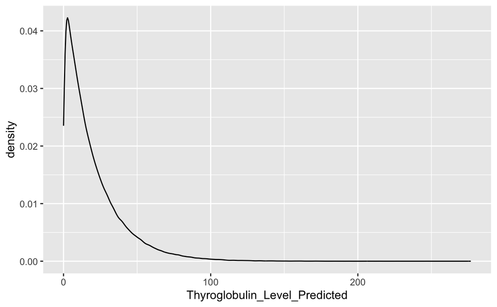

```r
thyro4 %>%
  ggplot(aes(
    x = Thyroglobulin_Level_Predicted,
  )) +
  geom_density(alpha = 0.50)
```

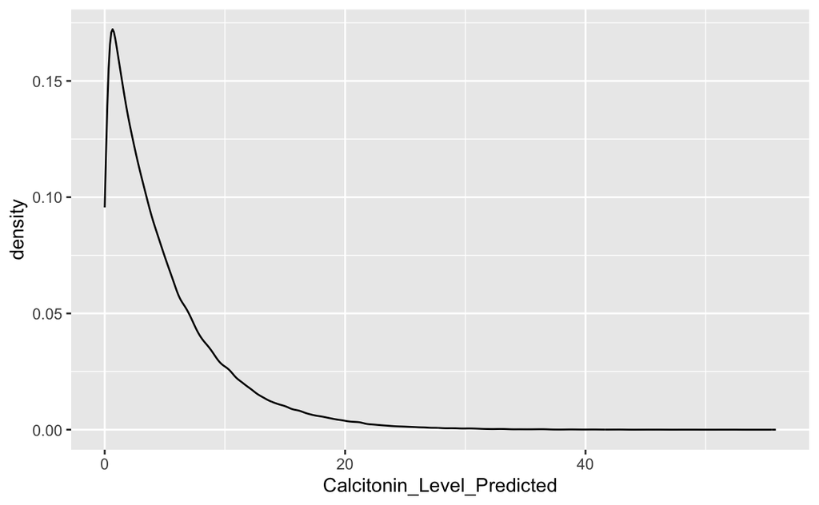

```r
thyro4 %>%
  ggplot(aes(
    x = Calcitonin_Level_Predicted
  )) +
  geom_density(alpha = 0.50)
```

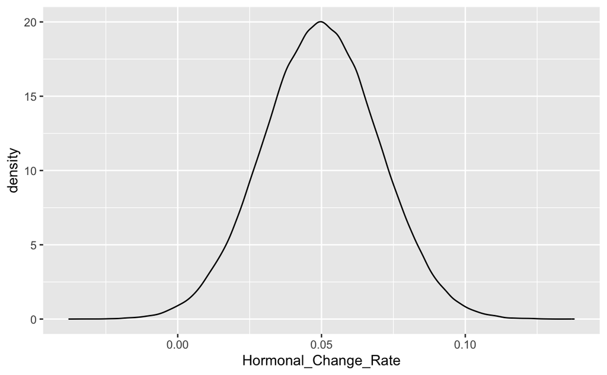

```r
thyro4 %>%
  ggplot(aes(
    x = Hormonal_Change_Rate
  )) +
  geom_density(alpha = 0.50)
```

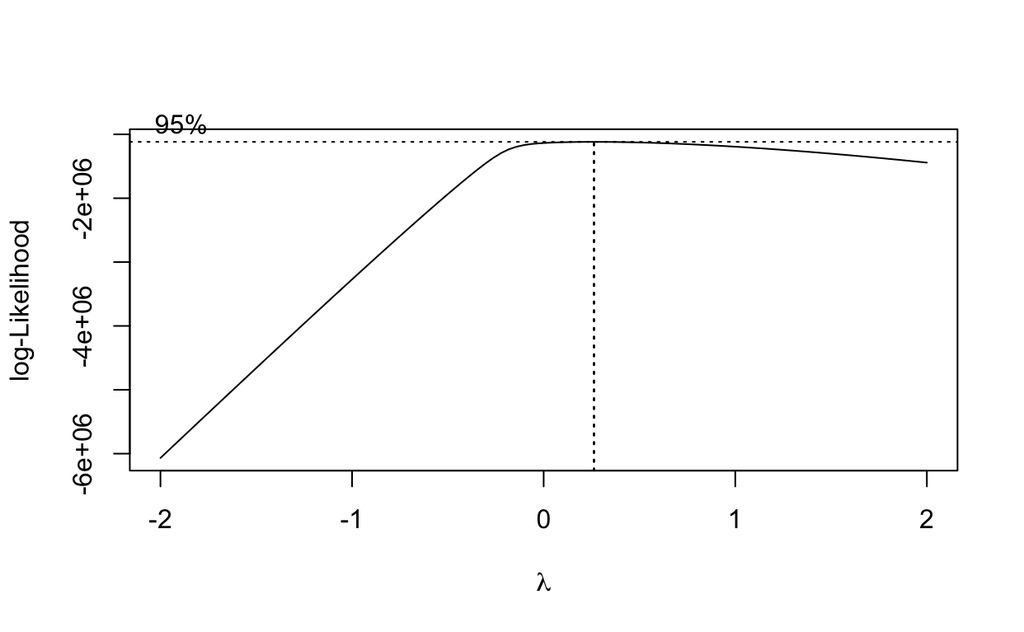

```r
m1 <- lm(Thyroglobulin_Level_Predicted + 1e-6 ~ 1, data = thyro4)
bc1 = MASS::boxcox(m1, plotit = TRUE)
```

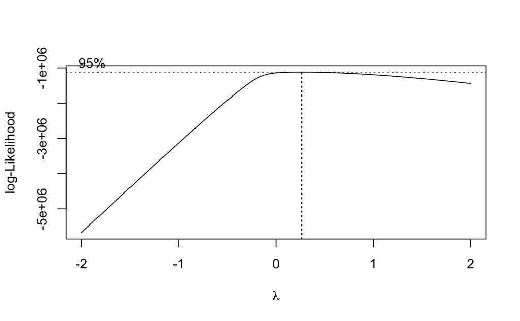

```r
optLamda_tg = bc1$x[which.max(bc1$y)]

m2 <- lm(Calcitonin_Level_Predicted + 1e-6 ~ 1, data = thyro4)
bc2 = MASS::boxcox(m2, plotit = TRUE)
```

```r
optLambda_calc = bc2$x[which.max(bc2$y)]

thyro4 = thyro4 %>%
  mutate(
    `bc(tg+1)` =
      ((Thyroglobulin_Level_Predicted + 1)^optLamda_tg - 1) / optLamda_tg,
    `bc(calc+1)` = ((Calcitonin_Level_Predicted + 1)^optLambda_calc -1) / optLambda_calc
  )
```

#### Exploratory Data Analysis

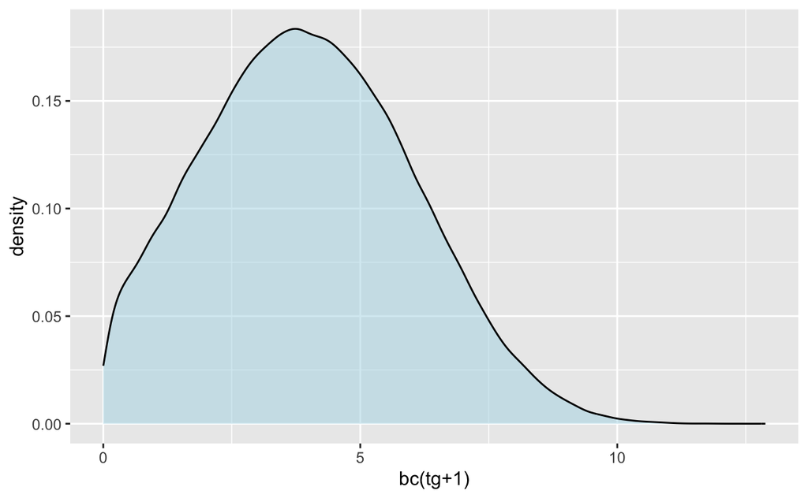

```r
thyro4 %>%
  ggplot(aes(
    x = `bc(tg+1)`,
  )) +
  geom_density(alpha = 0.50,
               fill = "lightblue")
```

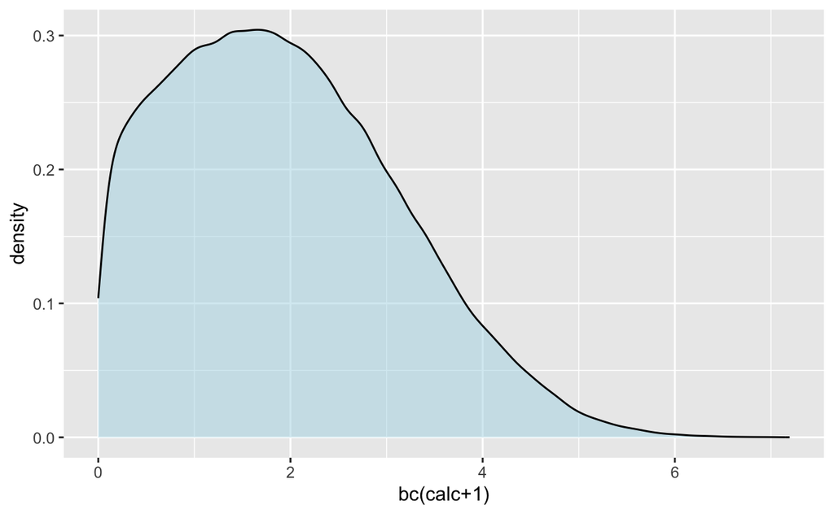

```r
thyro4 %>%
  ggplot(aes(
    x = `bc(calc+1)`
  )) +
  geom_density(alpha = 0.50,
               fill = "lightblue")
```

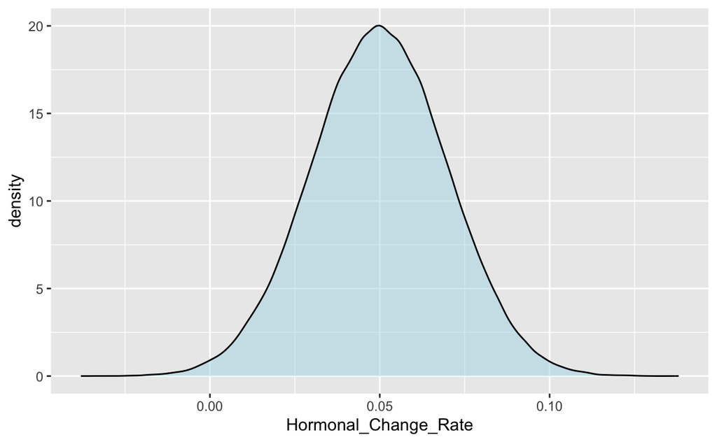

```r
thyro4 %>%
  ggplot(aes(
    x = Hormonal_Change_Rate
  )) +
  geom_density(alpha = 0.50,
               fill = "lightblue")
```

[figure not shown]

#### bc(Tg + 1) on bc(Calc + 1), bc(Tg + 1) on Hormonal, and bc(Calc + 1) on Horm.

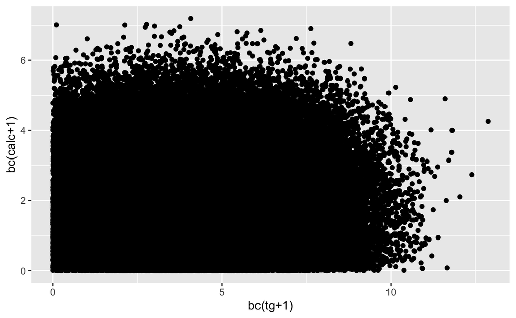

```r
thyro4 %>%
  ggplot(aes(x = `bc(tg+1)`, y = `bc(calc+1)`)) +
  geom_point()
```

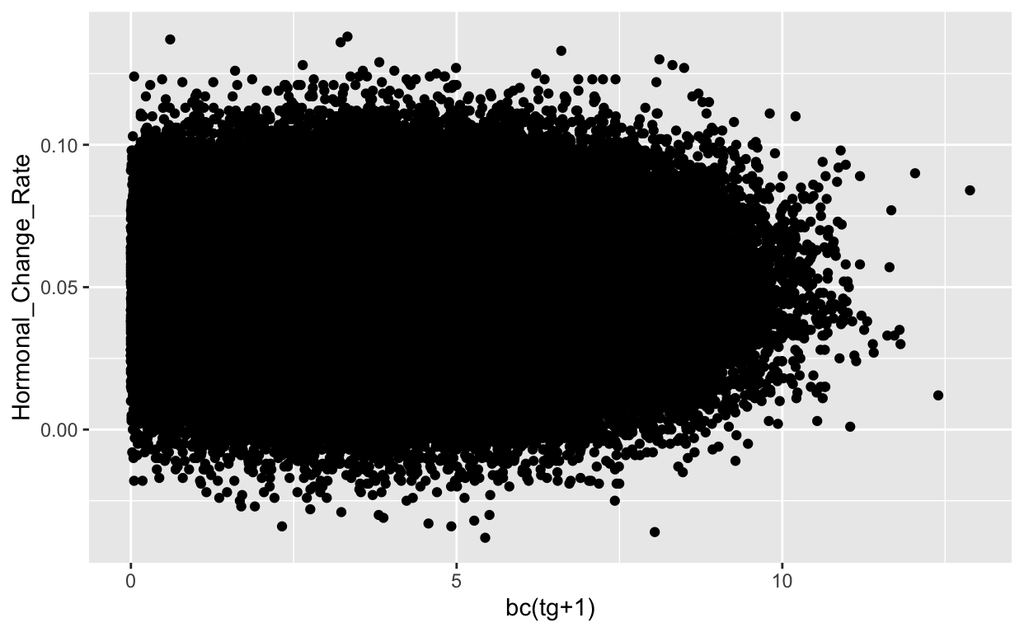

```r
thyro4 %>%
  ggplot(aes(x = `bc(tg+1)`, y = Hormonal_Change_Rate)) +
  geom_point()
```

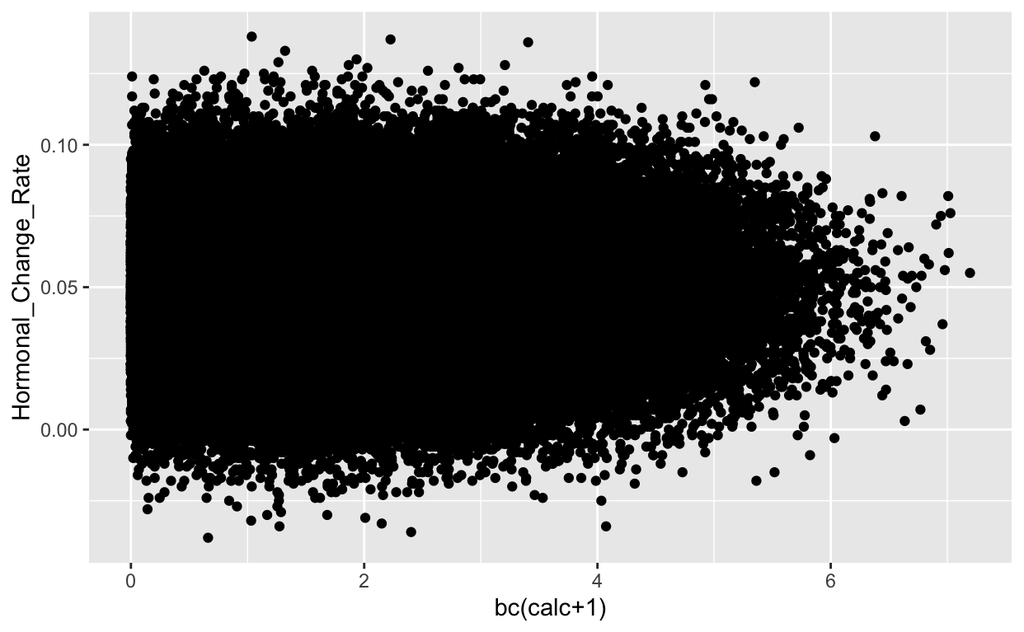

```r
thyro4 %>%
  ggplot(aes(x = `bc(calc+1)`, y = Hormonal_Change_Rate)) +
  geom_point()
```

```r
d1 = thyro4 %>%
  filter(elapsed_time_prop == 0 | elapsed_time_prop == 1) %>%
  group_by(
    factor(elapsed_time_prop),
    TSH_Risk_Level,
    Calcification_Presence,
    Capsular_Invasion_Indicator
    ) %>%
  summarize(
    median = median(`bc(tg+1)`),
    q1 = quantile(`bc(tg+1)`, 0.25),
    q3 = quantile(`bc(tg+1)`, 0.75)
  ) %>%
  as.data.frame()

d1.1 =
d1 %>%
  group_by(`factor(elapsed_time_prop)`) %>%
  summarize(median = median(median),
            q1 = median(q1),
            q3 = median(q3)
            ) %>%
  as.data.frame()
```

```r
p1 =
thyro4 %>%
  filter(elapsed_time_prop > 0 & elapsed_time_prop < 1) %>%
  ggplot(aes(x = elapsed_time_prop, y = `bc(tg+1)`)) +
  geom_point(alpha = 0.01) +
  geom_pointrange(aes(x = 1,
                  y = d1$median[2],
                  ymin = d1$q1[2],
                  ymax = d1$q3[2]
                  ),
                  colour = "steelblue3"
                  ) +
  geom_pointrange(aes(x = 0,
                  y = d1$median[1],
                  ymin = d1$q1[1],
                  ymax = d1$q3[1]
                  ),
                  colour = "steelblue3"
                  ) +
  geom_segment(
    aes(
      x = 0,
      xend = 1,
      y = d1$median[1],
      yend = d1$median[2]
    ),
    colour = "steelblue3"
  ) +
  theme(shape = 1) +
  theme_minimal()
```

```r
ggplot(data = center_Tg, aes(
  x = Visit_Number,
  y = med,
  ymin = q1,
  ymax = q3
))

###

ggplot(data = center_Calc, aes(
  x = Visit_Number,
  y = med,
  ymin = q1,
  ymax = q3,
  group = rank_visitFreq
)) +
  geom_point() +
  geom_errorbar(width = 0.05) +
  geom_point(aes(
    x = Visit_Number,
    y = min,
    colour = "steelblue2"
  )) +
  geom_point(aes(
    x = Visit_Number,
    y = max,
    colour = "lightpink2"
  )) +
  scale_colour_discrete(name = "Extremum", labels = c("Minimum", "Maximum")) +
  theme_minimal() +
  facet_wrap(vars(rank_visitFreq))

###

ggplot(data = center_Horm, aes(
  x = Visit_Number,
  y = med,
  ymin = q1,
  ymax = q3,
  group = rank_visitFreq
)) +
  geom_point() +
  geom_errorbar(width = 0.05) +
  geom_point(aes(
    x = Visit_Number,
    y = min,
    colour = "steelblue2"
  )) +
  geom_point(aes(
    x = Visit_Number,
    y = max,
    colour = "lightpink2"
  )) +
  scale_colour_discrete(name = "Extremum", labels = c("Minimum", "Maximum")) +
  theme_minimal() +
  facet_wrap(vars(rank_visitFreq))
```

[output not shown]

```r
wide_thyro4_Tg = thyro4 %>%
  pivot_wider(
    id_cols = Patient_ID,
    names_from = Visit_Number,
    values_from = `bc(tg+1)`,
    names_prefix = "tg"
  )

wide_thyro4_time = thyro4 %>%
  pivot_wider(
    id_cols = Patient_ID,
    names_from = Visit_Number,
    values_from = elapsed_time_prop,
    names_prefix = "prop_time"
  )

wide_thyro4_Calc = thyro4 %>%
  pivot_wider(
    id_cols = Patient_ID,
    names_from = Visit_Number,
    values_from = `bc(calc+1)`,
    names_prefix = "ct"
  )

wide_thyro4_Horm = thyro4 %>%
  pivot_wider(
    id_cols = Patient_ID,
    names_from = Visit_Number,
    values_from = Hormonal_Change_Rate,
    names_prefix = "horm"
  )

wide_TgXTime =
  left_join(x = wide_thyro4_Tg, y = wide_thyro4_time, by = "Patient_ID")

wide_CalcXTime =
  left_join(x = wide_thyro4_Calc, y = wide_thyro4_time, by = "Patient_ID")

wide_HormXTime =
  left_join(x = wide_thyro4_Horm, y = wide_thyro4_time, by = "Patient_ID")
```

```r
lgc_Tg <- '
  # Latent intercept
  i =~ 1*tg1 + 1*tg2 + 1*tg3 + 1*tg4 + 1*tg5

  # Latent slope (latent basis)
  s =~ 0*tg1 + l2*tg2 + l3*tg3 + l4*tg4 + 1*tg5

  # Latent means
  i ~ 1
  s ~ 1

  # Latent variances and covariance
  i ~~ i
  s ~~ s
  i ~~ s

  # Residual variances
  tg1 ~~ tg1
  tg2 ~~ tg2
  tg3 ~~ tg3
  tg4 ~~ tg4
  tg5 ~~ tg5
'

# Fit model using robust ML and FIML for missing data
fit <- growth(lgc_Tg,
              data = wide_TgXTime,
              missing = "fiml",
              estimator = "MLR")

summary(fit, fit.measures = TRUE, standardized = TRUE)
```

[output not shown]

```r
lgc_Tg <- '
  # Latent intercept
  i =~ 1*tg1 + 1*tg2 + 1*tg3 + 1*tg4 + 1*tg5

  # Latent slope (latent basis)
  s =~ 0*tg1 + l2*tg2 + l3*tg3 + l4*tg4 + 1*tg5

  # Latent means
  i ~ 1
  s ~ 1

  # Latent variances and covariance
  i ~~ i
  s ~~ s
  i ~~ s

  # Residual variances
  tg1 ~~ tg1
  tg2 ~~ tg2
  tg3 ~~ tg3
  tg4 ~~ tg4
  tg5 ~~ tg5
'

# Fit model using robust ML and FIML for missing data
fit <- growth(lgc_Tg,
              data = wide_TgXTime,
              missing = "fiml",
              estimator = "MLR")

summary(fit, fit.measures = TRUE, standardized = TRUE)
```

[output not shown]